# Practical Machine Learning. Assignment

tonuta

April 10, 2017

## Practical Machine Learning Course - *Project*

Clean the environment.

```r
rm(list = ls())
```

#### Install some R packages and upload libraries.

#### install.packages(“knitr”)

#### install.packages(“markdown”)

#### **Synopsis.**

Using devices such as Jawbone Up, Nike FuelBand, and Fitbit it is now possible to collect a large amount of data about personal activity relatively inexpensively. These type of devices are part of the quantified self movement - a group of enthusiasts who take measurements about themselves regularly to improve their health, to find patterns in their behavior, or because they are tech geeks. One thing that people regularly do is quantify how much of a particular activity they do, but they rarely quantify how well they do it. In this project, your goal will be to use data from accelerometers on the belt, forearm, arm, and dumbell of 6 participants. They were asked to perform barbell lifts correctly and incorrectly in 5 different ways. More information is available from the website here: http://groupware.les.inf.puc-rio.br/har (see the section on the Weight Lifting Exercise Dataset).

In this project of Practical machine Learning course, we will use data from accelerometers on the belt, forearm, arm, and dumbell of 6 participants to predict the manner in which they did the exercise.

#### **Project assignment.**

In this project of Practical machine Learning course, we will use data from accelerometers on the belt, forearm, arm, and dumbell of 6 participants to predict the manner in which they did the exercise.

#### **Goal of the project.**

The goal of your project is to predict the manner in which they did the exercise. This is the “classe” variable in the training set. You may use any of the other variables to predict with. You should create a report describing how you built your model, how you used cross validation, what you think the expected out of sample error is, and why you made the choices you did. You will also use your prediction model to predict 20 different test cases.

#### **Step 1: Perform the data exploration.**

The training data for this project are available here:

https://d396qusza40orc.cloudfront.net/predmachlearn/pml-training.csv

The test data are available here:

https://d396qusza40orc.cloudfront.net/predmachlearn/pml-testing.csv

The data for this project comes from this original source: http://groupware.les.inf.puc-rio.br/har.

However, I downloaded the file to my directory containing the programming environment.

The $na.string$ setting is used for the later removal of columns by setting cells with empty space to be $NA$.

```r
training.data <- read.csv("./Data/pml-training.csv", header = TRUE, sep = ",", stringsAsFactors = T, na.strings = c("", "NA"))

#class(training.data)
str(training.data)
```

```
## 'data.frame':    19622 obs. of  160 variables:
##  $ X                       : int  1 2 3 4 5 6 7 8 9 10 ...
##  $ user_name               : Factor w/ 6 levels "adelmo","carlitos",..: 2 2 2 2 2 2 2 2 2 2 ...
##  $ raw_timestamp_part_1    : int  1323084231 1323084231 1323084231 1323084232 1323084232 1323084232 1323084232 1323084232 1323084232 1323084232 ...
##  $ raw_timestamp_part_2    : int  788290 808298 820366 120339 196328 304277 368296 440390 484323 484434 ...
##  $ cvtd_timestamp          : Factor w/ 20 levels "02/12/2011 13:32",..: 9 9 9 9 9 9 9 9 9 9 ...
##  $ new_window              : Factor w/ 2 levels "no","yes": 1 1 1 1 1 1 1 1 1 1 ...
##  $ num_window              : int  11 11 11 12 12 12 12 12 12 12 ...
##  $ roll_belt               : num  1.41 1.41 1.42 1.48 1.48 1.45 1.42 1.42 1.43 1.45 ...
##  $ pitch_belt              : num  8.07 8.07 8.07 8.05 8.07 8.06 8.09 8.13 8.16 8.17 ...
##  $ yaw_belt                : num  -94.4 -94.4 -94.4 -94.4 -94.4 -94.4 -94.4 -94.4 -94.4 -94.4 ...
##  $ total_accel_belt        : int  3 3 3 3 3 3 3 3 3 3 ...
##  $ kurtosis_roll_belt      : Factor w/ 396 levels "-0.016850","-0.021024",..: NA NA NA NA NA NA NA NA NA NA ...
##  $ kurtosis_picth_belt     : Factor w/ 316 levels "-0.021887","-0.060755",..: NA NA NA NA NA NA NA NA NA NA ...
##  $ kurtosis_yaw_belt       : Factor w/ 1 level "#DIV/0!": NA NA NA NA NA NA NA NA NA NA ...
```

[output cut: 86 more lines]

```r
# print(head(training.data, 1))
dim(training.data)
```

```
## [1] 19622   160
```

#### **Step 2: Perform the data cleaning.**

#### **Step 2.1: Clean the training data**.

This step is used to remove the columns containing $NA$ and empty spaces along with columns that contain information that is unhelpful for the classification such as the index, date and participant’s names.

```r
training.cleaned.data <- training.data[8:length(training.data)]
remCol <-  colSums(is.na(training.cleaned.data))
training.cleaned.data <- training.cleaned.data[, remCol == 0]

#print(head(training.data, 12))
#print(tail(training.data, 12))
```

#### **Step 2.2: Split the upwards training data in training set and validation set**.

This step is related to the splitting of training data into a training set and a validation set. The validation set is necessary to estimate the performance of the classifier after it is trained based on the training set.

```r
require(caret)
set.seed(22519) # the set.seed function is chosen for getting reproductible results, when run mamy times.
inTrain <- createDataPartition(training.cleaned.data$classe, p = 3/4)[[1]]
training.set <- training.cleaned.data[inTrain, ]
validation.set <- training.cleaned.data[-inTrain, ]
```

```r
str(training.set)
```

```
## 'data.frame':    14718 obs. of  53 variables:
##  $ roll_belt           : num  1.41 1.42 1.48 1.42 1.42 1.43 1.45 1.43 1.45 1.48 ...
##  $ pitch_belt          : num  8.07 8.07 8.07 8.09 8.13 8.16 8.18 8.18 8.2 8.15 ...
##  $ yaw_belt            : num  -94.4 -94.4 -94.4 -94.4 -94.4 -94.4 -94.4 -94.4 -94.4 -94.4 ...
##  $ total_accel_belt    : int  3 3 3 3 3 3 3 3 3 3 ...
##  $ gyros_belt_x        : num  0 0 0.02 0.02 0.02 0.02 0.03 0.02 0 0 ...
##  $ gyros_belt_y        : num  0 0 0.02 0 0 0 0 0 0 0 ...
##  $ gyros_belt_z        : num  -0.02 -0.02 -0.02 -0.02 -0.02 -0.02 -0.02 -0.02 0 0 ...
##  $ accel_belt_x        : int  -21 -20 -21 -22 -22 -20 -21 -22 -21 -21 ...
##  $ accel_belt_y        : int  4 5 2 3 4 2 2 2 2 4 ...
##  $ accel_belt_z        : int  22 23 24 21 21 24 23 23 22 23 ...
##  $ magnet_belt_x       : int  -3 -2 -6 -4 -2 1 -5 -2 -1 0 ...
##  $ magnet_belt_y       : int  599 600 600 599 603 602 596 602 597 592 ...
##  $ magnet_belt_z       : int  -313 -305 -302 -311 -313 -312 -317 -319 -310 -305 ...
##  $ roll_arm            : num  -128 -128 -128 -128 -128 -128 -128 -128 -129 -129 ...
```

[output cut: 39 more lines]

```r
str(validation.set)
```

```
## 'data.frame':    4904 obs. of  53 variables:
##  $ roll_belt           : num  1.41 1.48 1.45 1.45 1.42 1.42 1.51 1.6 1.57 1.56 ...
##  $ pitch_belt          : num  8.07 8.05 8.06 8.17 8.2 8.21 8.12 8.1 8.09 8.1 ...
##  $ yaw_belt            : num  -94.4 -94.4 -94.4 -94.4 -94.4 -94.4 -94.4 -94.4 -94.4 -94.3 ...
##  $ total_accel_belt    : int  3 3 3 3 3 3 3 3 3 3 ...
##  $ gyros_belt_x        : num  0.02 0.02 0.02 0.03 0.02 0.02 0 0.02 0.02 0.02 ...
##  $ gyros_belt_y        : num  0 0 0 0 0 0 0 0 0.02 0 ...
##  $ gyros_belt_z        : num  -0.02 -0.03 -0.02 0 0 -0.02 -0.02 -0.02 -0.02 -0.02 ...
##  $ accel_belt_x        : int  -22 -22 -21 -21 -22 -22 -21 -20 -21 -21 ...
##  $ accel_belt_y        : int  4 3 4 4 4 4 4 1 3 4 ...
##  $ accel_belt_z        : int  22 21 21 22 21 21 22 20 21 21 ...
##  $ magnet_belt_x       : int  -7 -6 0 -3 -3 -8 -6 -10 -2 -4 ...
##  $ magnet_belt_y       : int  608 604 603 609 606 598 598 607 604 606 ...
##  $ magnet_belt_z       : int  -311 -310 -312 -308 -309 -310 -317 -304 -313 -311 ...
##  $ roll_arm            : num  -128 -128 -128 -128 -128 -128 -129 -129 -129 -129 ...
```

[output cut: 39 more lines]

```r
#Dimensionality for comparison:

dim(training.data)
```

```
## [1] 19622   160
```

```r
dim(training.cleaned.data)
```

```
## [1] 19622    53
```

```r
dim(training.set)
```

```
## [1] 14718    53
```

```r
dim(validation.set)
```

```
## [1] 4904   53
```

#### **Step 2.2: Assess the highly correlated variables**.

To asses if there are highly correlated variables, a correlation matrix is plotted.

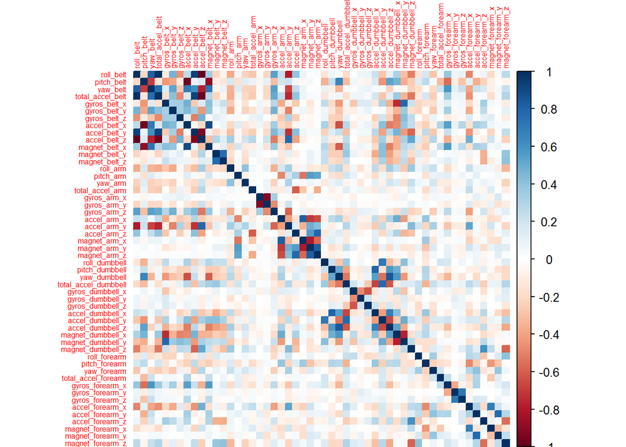

```r
library(corrplot)

correlMatrix <- cor(training.set[, -length(names(training.set))])
corrplot(correlMatrix, method = "color", tl.cex = 0.5)
```

#### **Step 3: Plot decision tree.**

```r
require(rpart)
```

[figure not shown]

```r
require(rpart.plot)
require(rattle)
decision.tree <- rpart(classe ~ ., data = training.set, method = "class")
fancyRpartPlot(decision.tree, cex = 0.2, tweak = 2, palettes = c("Greys", "Oranges", "Reds", "Greens"), sub = "Decision tree")
```

```r
# The gradient of the color in the decision tree represents the accuracy of that node.
```

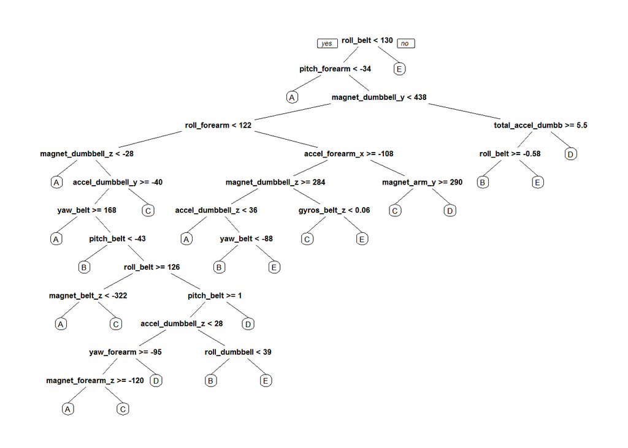

```r
decision.tree.2 <- rpart(classe ~ ., data = training.set, method = "class")
prp(decision.tree.2)
```

#### **Step 4: Model the data.**

A predictive model will be fitted using Random Forest algorithm. This fitting way selects important variables and is robust to correlated covariates & outliers. A five-fold cross-validation is used for this predictive model.

```r
require(randomForest)
random.forest.control <- trainControl(method = "cv", 5)
random.forest.model <- train(classe ~ ., data = training.set, method = "rf", trControl = random.forest.control, ntree = 10)
random.forest.model
```

```
## Random Forest
##
## 14718 samples
##    52 predictor
##     5 classes: 'A', 'B', 'C', 'D', 'E'
##
## No pre-processing
## Resampling: Cross-Validated (5 fold)
## Summary of sample sizes: 11775, 11774, 11772, 11776, 11775
## Resampling results across tuning parameters:
##
##   mtry  Accuracy   Kappa
##    2    0.9779867  0.9721520
##   27    0.9849839  0.9810045
##   52    0.9768308  0.9706881
##
## Accuracy was used to select the optimal model using  the largest value.
## The final value used for the model was mtry = 27.
```

The results of the confusion matrix command are as follows:

```r
random.forest.predict.1 <- predict(random.forest.model, training.set)
confusionMatrix(training.set$classe, random.forest.predict.1)
```

```
## Confusion Matrix and Statistics
##
##           Reference
## Prediction    A    B    C    D    E
##          A 4184    1    0    0    0
##          B    1 2844    2    0    1
##          C    0    1 2566    0    0
##          D    0    0    2 2410    0
##          E    0    0    0    2 2704
##
## Overall Statistics
##
##                Accuracy : 0.9993
##                  95% CI : (0.9988, 0.9997)
##     No Information Rate : 0.2843
##     P-Value [Acc > NIR] : < 2.2e-16
##
##                   Kappa : 0.9991
##  Mcnemar's Test P-Value : NA
##
## Statistics by Class:
##
##                      Class: A Class: B Class: C Class: D Class: E
## Sensitivity            0.9998   0.9993   0.9984   0.9992   0.9996
## Specificity            0.9999   0.9997   0.9999   0.9998   0.9998
## Pos Pred Value         0.9998   0.9986   0.9996   0.9992   0.9993
## Neg Pred Value         0.9999   0.9998   0.9997   0.9998   0.9999
## Prevalence             0.2843   0.1934   0.1746   0.1639   0.1838
## Detection Rate         0.2843   0.1932   0.1743   0.1637   0.1837
## Detection Prevalence   0.2843   0.1935   0.1744   0.1639   0.1839
## Balanced Accuracy      0.9998   0.9995   0.9992   0.9995   0.9997
```

Both the accuracy 0.9993 and the kappa indicator 0.9991 of concordance indicate that the model is well adjusted to the chosen parameters.

#### **Step 5: Estimate the performance of the model on the validation set.**

The results of the confusion matrix command are as follows:

```r
random.forest.predict <- predict(random.forest.model, validation.set)
confusionMatrix(validation.set$classe, random.forest.predict)
```

```
## Confusion Matrix and Statistics
##
##           Reference
## Prediction    A    B    C    D    E
##          A 1392    3    0    0    0
##          B    7  927   12    3    0
##          C    0    8  842    5    0
##          D    0    1   11  792    0
##          E    0    2    4    6  889
##
## Overall Statistics
##
##                Accuracy : 0.9874
##                  95% CI : (0.9838, 0.9903)
##     No Information Rate : 0.2853
##     P-Value [Acc > NIR] : < 2.2e-16
##
##                   Kappa : 0.984
##  Mcnemar's Test P-Value : NA
##
## Statistics by Class:
##
##                      Class: A Class: B Class: C Class: D Class: E
## Sensitivity            0.9950   0.9851   0.9689   0.9826   1.0000
## Specificity            0.9991   0.9944   0.9968   0.9971   0.9970
## Pos Pred Value         0.9978   0.9768   0.9848   0.9851   0.9867
## Neg Pred Value         0.9980   0.9965   0.9933   0.9966   1.0000
## Prevalence             0.2853   0.1919   0.1772   0.1644   0.1813
## Detection Rate         0.2838   0.1890   0.1717   0.1615   0.1813
## Detection Prevalence   0.2845   0.1935   0.1743   0.1639   0.1837
## Balanced Accuracy      0.9971   0.9898   0.9829   0.9899   0.9985
```

Both the accuracy 0.9874 and the kappa indicator 0.984 of concordance indicate that the predictor seems to have a low out of sample error rate.

```r
model.accuracy <- postResample(random.forest.predict, validation.set$classe)
print(model.accuracy)
```

```
##  Accuracy     Kappa
## 0.9873573 0.9840081
```

```r
oose <- 1 - as.numeric(confusionMatrix(validation.set$classe, random.forest.predict)$overall[1])
oose
```

```
## [1] 0.01264274
```

#### **Step 6: Load the testing data and clean it.**

The test data cleaning is done in the same way as the training data: removing the columns containing $NA$ and emptying spaces along with columns that contain information which is unhelpful for the classification such as the index, date and participant’s names.

```r
test.data <- read.csv("./Data/pml-testing.csv", header = TRUE, sep = ",", stringsAsFactors = T, na.strings = c("", "NA"))
```

```r
test.cleaned.data <- test.data[8:length(test.data)]
remCol <-  colSums(is.na(test.cleaned.data))
test.cleaned.data <- test.cleaned.data[, remCol == 0]
```

```r
str(test.cleaned.data)
```

```
## 'data.frame':    20 obs. of  53 variables:
##  $ roll_belt           : num  123 1.02 0.87 125 1.35 -5.92 1.2 0.43 0.93 114 ...
##  $ pitch_belt          : num  27 4.87 1.82 -41.6 3.33 1.59 4.44 4.15 6.72 22.4 ...
##  $ yaw_belt            : num  -4.75 -88.9 -88.5 162 -88.6 -87.7 -87.3 -88.5 -93.7 -13.1 ...
##  $ total_accel_belt    : int  20 4 5 17 3 4 4 4 4 18 ...
##  $ gyros_belt_x        : num  -0.5 -0.06 0.05 0.11 0.03 0.1 -0.06 -0.18 0.1 0.14 ...
##  $ gyros_belt_y        : num  -0.02 -0.02 0.02 0.11 0.02 0.05 0 -0.02 0 0.11 ...
##  $ gyros_belt_z        : num  -0.46 -0.07 0.03 -0.16 0 -0.13 0 -0.03 -0.02 -0.16 ...
##  $ accel_belt_x        : int  -38 -13 1 46 -8 -11 -14 -10 -15 -25 ...
##  $ accel_belt_y        : int  69 11 -1 45 4 -16 2 -2 1 63 ...
##  $ accel_belt_z        : int  -179 39 49 -156 27 38 35 42 32 -158 ...
##  $ magnet_belt_x       : int  -13 43 29 169 33 31 50 39 -6 10 ...
##  $ magnet_belt_y       : int  581 636 631 608 566 638 622 635 600 601 ...
##  $ magnet_belt_z       : int  -382 -309 -312 -304 -418 -291 -315 -305 -302 -330 ...
##  $ roll_arm            : num  40.7 0 0 -109 76.1 0 0 0 -137 -82.4 ...
```

[output cut: 39 more lines]

```r
dim(test.cleaned.data)
```

```
## [1] 20 53
```

#### **Step 7: Fit the testing data based on the developed model.**

```r
test.results.predict <- predict(random.forest.model, test.cleaned.data[, -length(names(test.cleaned.data))])
test.results.predict
```

```
##  [1] B A B A A E D B A A B C B A E E A B B B
## Levels: A B C D E
```

#### **Step 8: Conclusions**.

A model is built to predict physical exercises based on movement data. An estimatation of the out-of-sample error is 1%. This is a promising result regarding the use of machine learning to detect bad exercises.

```r
function.write.files <- function(y)  {
  m <- length(y)
  path <- "I:/Coursera/Data Science Specialization/Course8_Machine learning/Assignments"
  for(j in 1:m)  {
    filename <- paste0("test_case_", j, ".txt")
    write.table(y[j], file = filename, row.names = FALSE, col.names = FALSE, quote = FALSE)
  }
}

function.write.files(test.results.predict)
```

#### **Step 9: R version and System information for this analysis.**

```r
Sys.info()[1:2]
```

```
##   sysname   release
## "Windows"   "7 x64"
```

```r
R.version.string
```

```
## [1] "R version 3.2.4 Revised (2016-03-16 r70336)"
```